# Géostatistique

Marie-Pierre Etienne

marie-pierre.etienne@ensai.fr

ENSAI - CREST

https://marieetienne.github.io/statspat

2026-11-23

# Introduction

## Sources

Ce cours est construit principalement à partir de celui de Lilane Bel et du livre de Gaetan et al. (2010)

## Exemple illustratif

La température en France

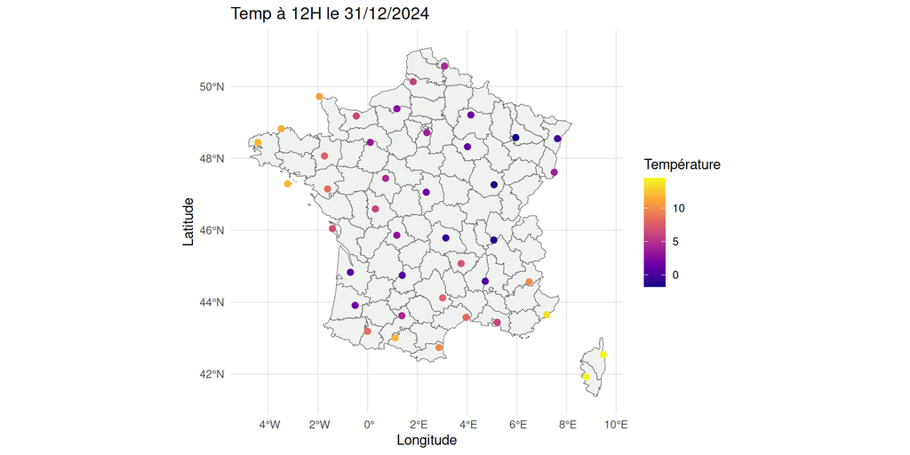

## Géostatistique

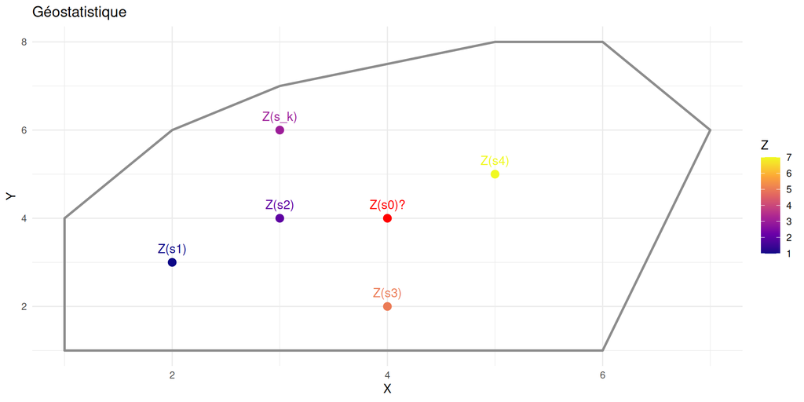

- Domaine continu : $D \subset \mathbb{R}^2$.
- Processus stochastique : $Z = \{Z(s)\}_{s \in D}$
  - Collection de variables aléatoires indexées par $s \in D$.
  - Données $Z(s_1), Z(s_2), \ldots, Z(s_n)$ observés.

### Objectifs :

- Prédiction $\widehat{Z}(s_0)$ de $Z(s_0)$ ou intégrale $\int_B Z(s)ds$.
- Estimation de la loi de $Z(s)$ ou d’une fonctionnelle $\varphi(Z(s))$.
- Estimation des relations de dépendance entre $Z(s_i)$.

## Intuition

- Que veut on prendre en compte ?
- Quid des répétitions ?
- Que peut-on espérer estimer, comprendre ?

## Estimation de la moyenne

### Hypothèses

- $E(Z(s)) = \mu \quad \forall s \in D$
- $\text{cov}(Z(s_i), Z(s_j)) = c_{ij}$

### Estimation

- Observations : $Z(s_1), Z(s_2), \ldots, Z(s_n)$.
- Estimation de $E(Z(s)) = \mu$ ?

### Contraintes

- Estimateur linéaire : $\widehat{\mu} = \sum_{i=1}^n \lambda_i Z(s_i)$.
- Sans biais : $\text{E}(\widehat{\mu}) = \mu$.
- Variance minimale : $\text{Var}(\widehat{\mu} - \mu)$.

## Estimation de la moyenne

- Si $\widehat{\mu}$ est sans biais alors
- Quelle est la conséquence de l’hypothèse de variance minimale ?

## Solution : Best Linear Unbiased Estimator (BLUE)

- Minimisation :
  $$\min \sum_{i,j=1}^n \lambda_i \lambda_j c_{ij} \quad ; \quad \sum_{i=1}^n \lambda_i = 1$$

Utiliser la méthode du multiplicateur de Lagrange et montrer qu’on cherche à résoudre le système linéaire

$$\begin{pmatrix}
c_{11} & c_{12} & \dots & c_{1n} & 1 \\
c_{21} & c_{22} & \dots & c_{2n} & 1 \\
\vdots & \vdots & \ddots & \vdots & \vdots \\
c_{n1} & c_{n2} & \dots & c_{nn} & 1 \\
1 & 1 & \dots & 1 & 0
\end{pmatrix}
\begin{pmatrix}
\lambda_1 \\
\lambda_2 \\
\vdots \\
\lambda_n \\
m
\end{pmatrix} =
\begin{pmatrix}
0 \\
0 \\
\vdots \\
0 \\
1
\end{pmatrix}$$

Conclusion si $c_{ij}$ connus, on peut estimer la moyenne

Encore faut il pouvoir estimer la covariance

## Spécificité des données spatiales

- on a souvent une seule réalisation du processus spatial
- Il faut avoir des hypothèses de régularité spatial pour espérer dire des choses à partir d’une réalisation

# Processus du second ordre

## Définitions

- $Z$ est un processus du second ordre si $\forall s \in D, \text{E}(Z(s)^2) < \infty$.
- La moyenne de $Z$ est la fonction
  $$\begin{align}
  m : D & \to {\mathbb{R}}\\
  s & \to m(s) = {\mathbb{E}}(Z(s)))
  \end{align}$$
- La covariance de $Z$ est la fonction
  $$\begin{align}
  c : D\times D & \to {\mathbb{R}}\\
  (s,t) & \to c(s,t) = {\mathbb{C}\text{ov}}(Z(s), Z(t))
  \end{align}$$

**Propriété** Une fonction de covariance est semi définie positive i.e.

$$\forall a\in {\mathbb{R}}^n, \sum_{i,j}^n a_i a_j C(s_i, s_j)\geq 0$$
Idée de preuve : Regarder ${\mathbb{V}\text{ar}}(\sum_{i=1}^n a_i Z(s_i))$

- $Z$ est un processus gaussien si pour toute partie finie $S \subset D$ et toute suite réelle $a = (a_s , s\in S)$, $\sum_{s\in S} a_s Z(s)$ est une variable gaussienne.

## Processus stationnaire

### Définition

Un processus de second ordre $Z$ est stationnaire sur $D\subset {\mathbb{R}}^d$ si

1. Moyenne constante : $\forall s\in D, \quad m(s) = \mu$.
2. Covariance invariante par translation :
   $$\forall (s, t)\in D^2
   c(s,t) = C(t - s) \quad \text{ou} \forall h; s+h \in D, \quad c(s,s+h) = C(h)$$

### Isotropie

Un processus est isotrope si $C(h)$ dépend uniquement de $\|h\|$ i.e
$$C(h) = C(\|h\|)$$

## Stationarité des accroissements

$Z$ est un processus à accroissements stationnaires si les accroissements de $Z$ sont stationnaires au second ordre, i.e.
$${\mathbb{E}}(Z(s + h) − Z(s)) = 0$$
$${\mathbb{V}\text{ar}}(Z(s + h) − Z(s)) = 2\gamma(h)$$
La stationnarité du second ordre implique la stationnarité des accroissements.

La classe des processus à accroissement stations est donc plus ….. que la classe des processus de second ordre. ### Exemple

Que dire du mouvement Brownien sur ${\mathbb{R}}$

# Variogramme

## Définition

Le semi-variogramme d’un processus à accroissements stattionnaire est défini comme :
$$\gamma(h) = \frac{1}{2} {\mathbb{V}\text{ar}}(Z(s+h) - Z(s))$$

### Propriétés

- $\gamma(h) \geq 0$, $\gamma(0) = 0$, $\gamma(-h) = \gamma(h)$.
- Si $Z$ est stationnaire de second ordre :
  $$\gamma(h) = C(0) - C(h)$$
- si $lim_{|h|\to \infty} \gamma(h) = \ell < +\infty$ alors le processus est stationnaire du second ordre et $\ell = C(0)$

## Variogrammes classiques

1. **Pépitique** : $\gamma(h) = C$
2. **Exponentiel** : $\gamma(h) = C(1 - \exp(-\|h\|/\rho))$.
3. **Sphérique** :
   $$\gamma(h) = \begin{cases}
   C \left( \frac{3}{2} \frac{\|h\|}{\rho} - \frac{1}{2} \left(\frac{\|h\|}{\rho}\right)^3 \right) & \text{si } \|h\| \leq \rho \\
   C & \text{si } \|h\| > \rho
   \end{cases}$$
4. **Gaussien** : $\gamma(h) = C(1 - \exp(-\|h\|^2/\rho))$.
5. **Puissance** : $\gamma(h) = C\left | h\right|^\alpha, \alpha < 2$

## Un variogramme particulier

**Classe de Matèrn**

$$\gamma(h) = C\left [ 1 - \frac{1}{2^{\nu -1}\Gamma(\nu)}\left(\frac{\sqrt{2\nu }h}{\rho}\right)K_{\nu}\left(\frac{\sqrt{2\nu }h}{\rho}\right)\right]$$
$K_{\nu}$ fonction de Bessel modifiée de 3ème espèce, d’ordre $\nu$

$\nu$ paramètre qui règle la régularité en 0.

- $\nu$ = 1/2 : modèle exponentiel
- $\nu\to \infty$

## Effet des paramètres

- palier $C = \lim_{h \to \infty} \gamma(h)$}
- échelle $\rho$
- portée $\widetilde{\rho} \mbox{ t.q. } \|h\| \ge \widetilde{\rho} \rightarrow C - \gamma(h) \le \varepsilon$
- pépite $\tau = \lim_{h \to 0} \gamma(h)$

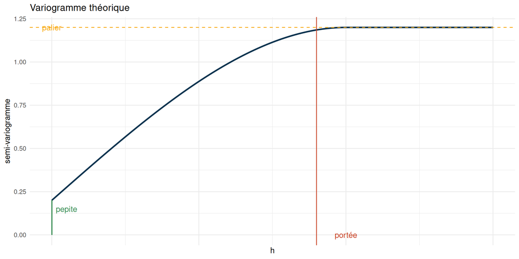

## Effet des paramètres

- Le palier : S’il est fini, le processus $Z$ est stationnaire du second ordre et
  $$C = \mbox{Var}(Z(s))$$
- L’échelle : Règle la vitesse à laquelle le variogramme rejoint le palier. Donne une idée de l’horizon de dépendance du processus.
- La portée est la distance à partir de laquelle la corrélation est nulle ou négligeable
- La pépite donne la régularité du processus
  - si $\tau\neq 0$ le processus est très irrégulier (bruit blanc, erreur de mesure)
  - si $\tau=0$, la régularité du variogramme en 0 (paramètre $\nu$ dans le variogramme de Matern)

# Estimation du variogramme

## Intuition

- Quelles données pour le variogramme
- Comment peut-on s’y prendre

## Nuée Variographique

$$\gamma(h) =\frac{1}{2} {\mathbb{V}\text{ar}}(Z(s+h) - Z(s)) = \frac{1}{2} {\mathbb{E}}( (Z(s+h) - Z(s))^2 )$$

On cherche donc à associer à chaque $h$, $0.5 {\mathbb{E}}( (Z(s+h) - Z(s))^2 )$, on va approcher cette espérance par $0.5 \left (Z(s_i)- Z(s_j) \right)^2$

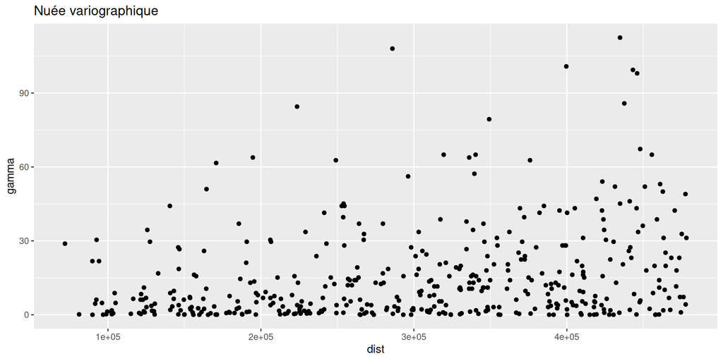

```r
temp_df <- temp_df |> st_transform(crs = "EPSG:2154" )
vario.cloud = variogram(temp_moy~1, data = temp_df, cloud = TRUE)
vario.cloud |> ggplot(aes(x=dist, y =gamma)) + geom_point() + ggtitle("Nuée variographique")
```

## Variogramme expérimental

$$\widetilde \gamma (d_k) = \frac{1}{2n_c}\sum_{(k-1)\delta \le \|s_i-s_j\| \le k\delta}(Z(s_i)-Z(s_j))^2$$

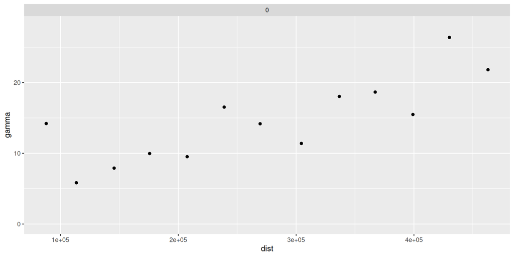

```r
vario.b = variogram(temp_moy~1, data = temp_df
                    # , alpha=c(0,45,90,135)
                    )
ggplot(data = vario.b, aes(x=dist, y =gamma)) + facet_wrap(~dir.hor) + geom_point() + ylim(c(0, 28))
```

## Propriétés du variogramme expérimental

```
* sans biais,
* sous des conditions de mélange, loi limite gaussienne, $\quad$ variance en $\frac{1}{n}$,
* ne nécessite pas l'estimation de la moyenne,
* si $Z$ est gaussien, somme de $\chi^2(1)$
```

### Estimateur robuste

$$\widetilde \gamma (d_k) = \left\{\frac{1}{2n_c}\sum_{i,j \in C(k)}(Z(s_i)-Z(s_j))^2\right\}^{1/4}\frac{1}{0.457 + \frac{0.494}{n_c}}$$

## Ajustement du variogramme

$\gamma_{\rho,C,\nu,\tau}$ variogramme admissible, $(\rho,\nu, C, \tau)$ solution du problème
$$\min_{\rho,C,\nu,\tau} \sum_{k=1}^K (\gamma_{\rho,C,\nu,\tau}(d_k) - \widetilde \gamma(d_k))^2$$

Autres méthodes possibles : max de vraisemblance, moindres carrés généralisés

# Prédiction : le krigeage

## Objectif

On observe $z(s_1),z(s_2),\ldots,z(s_n)$ aux sites $s_1,s_2,\ldots,s_n$ et on veut prédire $g(Z(s))$, $s\in D$

Par exemple

- $Z(s_0)$, $s_0$ non observé,
- $\frac{1}{|B|}\int_B Z(s)ds \quad B \mbox{ région de } D$,
- $P(Z(s_0)>\zeta)$

## Prédicteur optimal

Prédire $Z(s_0)$ sachant $Z(s_1)=z(s_1),\ldots,Z(s_n)=z(s_n)$

Prédicteur optimal

Par la propriété de l’espérance conditionnelle, le prédicteur optimal est

$$p^{opt}_{s_0}(Z(s_1),\ldots,Z(s_n)) = \mbox{E}\big(Z(s_0)/Z(s_1),\ldots,Z(s_n)\big)$$
puisqu’il minimise le risque quadratique
$$\mbox{E}\big((Z(s_0)-\widehat{Z}(s_0))^2\big)$$

Prédicteur linéaire optimal (BLUP)
$$p^* = \alpha + \sum_{i=1}^n\lambda_i Z(s_i)$$
Si $Z$ gaussien, $p^{opt}=p^*$

Solution

$$\begin{align}
\lambda &= C^{-1}c \qquad C_{i,j} = \mbox{cov}\big(Z(s_i),Z(s_j)\big)
\quad c_i = \mbox{cov}\big(Z(s_0),Z(s_i)\big)\\
\alpha = & \mbox{E}(Z(s_0)) - \sum_{i=1}^n\lambda_i \mbox{E}(Z(s_i))
\end{align}$$

## Krigeage simple

Supposons $C$ et $m(s)$ connues
$$\widehat{Z(s_0)} = \; c^T C^{-1}(Z-m) + m(s_0)$$
Variance de krigeage
$$\sigma^2_{SK} = \sigma^2(s_0) - c^TC^{-1}c$$
Si $s_0=s_i$, alors
$$\widehat{Z(s_i)}=Z(s_i)$$

Il faut estimer $C$ et $m(s)$.

## Krigeage universel

Hypothèses : $Z(s) = X\beta + \epsilon(s)$,

On cherche $\widehat{Z}(s_0) = \sum_{i=1}^n\lambda_iZ(s_i)$} avec
$$E(\widehat{Z}(s_0)) = E(Z(s_0)) \mbox{ et } E(\widehat{Z}(s_0) - Z(s_0))^2 \mbox{ minimum}$$

Covariance : $C(h) = Cov(Z(s+h),Z(s))$, $\boldsymbol{\Sigma}$ the covariance matrix ($\Sigma_{ij}= C(s_j-s_i)$), $\boldsymbol{c_0}$ the covariance vector ($c_j =C(s_o-s_j)$)

Proposition :

$$\widehat{Z}(s_0) = \left \lbrace \boldsymbol{c_0}^T \boldsymbol{\Sigma}^{-1} + (X_0 - X^T \boldsymbol{\Sigma}^{-1} \boldsymbol{c_0})^T (X^T \boldsymbol{\Sigma}^{-1} X)^{-1} X^T \boldsymbol{\Sigma}^{-1} \right\rbrace Z$$
$$\tau^2(s_0) = \sigma_0^2 - \mathbf{c_0}^T \mathbf{\Sigma}^{-1} \mathbf{c_0}
+ \left( X_0 - \mathbf{X}^T \mathbf{\Sigma}^{-1} \mathbf{c_0} \right)^T
\left( \mathbf{X}^T \mathbf{\Sigma}^{-1} \mathbf{X} \right)^{-1}
\left( X_0 - \mathbf{X}^T \mathbf{\Sigma}^{-1} \mathbf{c_0} \right)$$

Remarques

1. On n’a pas forcément $0 \le \lambda_i \le 1$
2. Si $s_0 \in \{ s_1,\ldots s_n\}$ alors $\lambda_i = 1$, $\lambda_j=0$, $j\neq i$}, et $\sigma_K^2(s_i)=0$
3. les poids de krigeage $\lambda_i$ dépendent de la disposition des sites de données, de la localisation du site de prédiction, du nombre de données et de la fonction variogramme.

## En pratique

Voir le [TD](https://marieetienne.github.io/statspat/01_pluies.html#/title-slide)

## Références

Gaetan, Carlo, Xavier Guyon, et al. 2010. *Spatial Statistics and Modeling*. Vol. 90. Springer.